# Risk Factor Analysis

## Outcome Variable

**Outcome Variable:** wast_rec90d

## Predictor Variables

**Intervention Variable:** birthwt

**Adjustment Set:**

unadjusted

## Stratifying Variables

The analysis was stratified on these variable(s):

- agecat
- studyid
- country

## Data Summary

| agecat | studyid | country | birthwt | wast_rec90d | n_cell | n |
| --- | --- | --- | --- | --- | --- | --- |
| 0-24 months | ki0047075b-MAL-ED | BANGLADESH | Normal or high birthweight | 0 | 31 | 122 |
| 0-24 months | ki0047075b-MAL-ED | BANGLADESH | Normal or high birthweight | 1 | 46 | 122 |
| 0-24 months | ki0047075b-MAL-ED | BANGLADESH | Low birthweight | 0 | 12 | 122 |
| 0-24 months | ki0047075b-MAL-ED | BANGLADESH | Low birthweight | 1 | 33 | 122 |
| 0-24 months | ki0047075b-MAL-ED | BRAZIL | Normal or high birthweight | 0 | 5 | 24 |
| 0-24 months | ki0047075b-MAL-ED | BRAZIL | Normal or high birthweight | 1 | 16 | 24 |
| 0-24 months | ki0047075b-MAL-ED | BRAZIL | Low birthweight | 0 | 1 | 24 |
| 0-24 months | ki0047075b-MAL-ED | BRAZIL | Low birthweight | 1 | 2 | 24 |
| 0-24 months | ki0047075b-MAL-ED | INDIA | Normal or high birthweight | 0 | 44 | 166 |
| 0-24 months | ki0047075b-MAL-ED | INDIA | Normal or high birthweight | 1 | 78 | 166 |
| 0-24 months | ki0047075b-MAL-ED | INDIA | Low birthweight | 0 | 20 | 166 |
| 0-24 months | ki0047075b-MAL-ED | INDIA | Low birthweight | 1 | 24 | 166 |
| 0-24 months | ki0047075b-MAL-ED | NEPAL | Normal or high birthweight | 0 | 13 | 90 |
| 0-24 months | ki0047075b-MAL-ED | NEPAL | Normal or high birthweight | 1 | 60 | 90 |
| 0-24 months | ki0047075b-MAL-ED | NEPAL | Low birthweight | 0 | 3 | 90 |
| 0-24 months | ki0047075b-MAL-ED | NEPAL | Low birthweight | 1 | 14 | 90 |
| 0-24 months | ki0047075b-MAL-ED | PERU | Normal or high birthweight | 0 | 3 | 35 |
| 0-24 months | ki0047075b-MAL-ED | PERU | Normal or high birthweight | 1 | 23 | 35 |
| 0-24 months | ki0047075b-MAL-ED | PERU | Low birthweight | 0 | 3 | 35 |
| 0-24 months | ki0047075b-MAL-ED | PERU | Low birthweight | 1 | 6 | 35 |
| 0-24 months | ki0047075b-MAL-ED | SOUTH AFRICA | Normal or high birthweight | 0 | 17 | 85 |
| 0-24 months | ki0047075b-MAL-ED | SOUTH AFRICA | Normal or high birthweight | 1 | 54 | 85 |
| 0-24 months | ki0047075b-MAL-ED | SOUTH AFRICA | Low birthweight | 0 | 1 | 85 |
| 0-24 months | ki0047075b-MAL-ED | SOUTH AFRICA | Low birthweight | 1 | 13 | 85 |
| 0-24 months | ki0047075b-MAL-ED | TANZANIA, UNITED REPUBLIC OF | Normal or high birthweight | 0 | 6 | 39 |
| 0-24 months | ki0047075b-MAL-ED | TANZANIA, UNITED REPUBLIC OF | Normal or high birthweight | 1 | 31 | 39 |
| 0-24 months | ki0047075b-MAL-ED | TANZANIA, UNITED REPUBLIC OF | Low birthweight | 0 | 0 | 39 |
| 0-24 months | ki0047075b-MAL-ED | TANZANIA, UNITED REPUBLIC OF | Low birthweight | 1 | 2 | 39 |
| 0-24 months | ki1000108-CMC-V-BCS-2002 | INDIA | Normal or high birthweight | 0 | 97 | 324 |
| 0-24 months | ki1000108-CMC-V-BCS-2002 | INDIA | Normal or high birthweight | 1 | 173 | 324 |

[output cut: 282 more lines]

The following strata were considered:

- agecat: 0-24 months, studyid: ki0047075b-MAL-ED, country: BANGLADESH
- agecat: 0-24 months, studyid: ki0047075b-MAL-ED, country: BRAZIL
- agecat: 0-24 months, studyid: ki0047075b-MAL-ED, country: INDIA
- agecat: 0-24 months, studyid: ki0047075b-MAL-ED, country: NEPAL
- agecat: 0-24 months, studyid: ki0047075b-MAL-ED, country: PERU
- agecat: 0-24 months, studyid: ki0047075b-MAL-ED, country: SOUTH AFRICA
- agecat: 0-24 months, studyid: ki0047075b-MAL-ED, country: TANZANIA, UNITED REPUBLIC OF
- agecat: 0-24 months, studyid: ki1000108-CMC-V-BCS-2002, country: INDIA
- agecat: 0-24 months, studyid: ki1000108-IRC, country: INDIA
- agecat: 0-24 months, studyid: ki1000109-EE, country: PAKISTAN
- agecat: 0-24 months, studyid: ki1000109-ResPak, country: PAKISTAN
- agecat: 0-24 months, studyid: ki1000304b-SAS-CompFeed, country: INDIA
- agecat: 0-24 months, studyid: ki1017093-NIH-Birth, country: BANGLADESH
- agecat: 0-24 months, studyid: ki1017093b-PROVIDE, country: BANGLADESH
- agecat: 0-24 months, studyid: ki1017093c-NIH-Crypto, country: BANGLADESH
- agecat: 0-24 months, studyid: ki1066203-TanzaniaChild2, country: TANZANIA, UNITED REPUBLIC OF
- agecat: 0-24 months, studyid: ki1101329-Keneba, country: GAMBIA
- agecat: 0-24 months, studyid: ki1113344-GMS-Nepal, country: NEPAL
- agecat: 0-24 months, studyid: ki1114097-CMIN, country: BANGLADESH
- agecat: 0-24 months, studyid: ki1119695-PROBIT, country: BELARUS
- agecat: 0-24 months, studyid: ki1126311-ZVITAMBO, country: ZIMBABWE
- agecat: 0-24 months, studyid: ki1135781-COHORTS, country: GUATEMALA
- agecat: 0-24 months, studyid: ki1135781-COHORTS, country: INDIA
- agecat: 0-24 months, studyid: ki1135781-COHORTS, country: PHILIPPINES
- agecat: 0-24 months, studyid: kiGH5241-JiVitA-3, country: BANGLADESH
- agecat: 0-24 months, studyid: kiGH5241-JiVitA-4, country: BANGLADESH
- agecat: 0-6 months, studyid: ki0047075b-MAL-ED, country: BANGLADESH
- agecat: 0-6 months, studyid: ki0047075b-MAL-ED, country: BRAZIL
- agecat: 0-6 months, studyid: ki0047075b-MAL-ED, country: INDIA
- agecat: 0-6 months, studyid: ki0047075b-MAL-ED, country: NEPAL
- agecat: 0-6 months, studyid: ki0047075b-MAL-ED, country: PERU
- agecat: 0-6 months, studyid: ki0047075b-MAL-ED, country: SOUTH AFRICA
- agecat: 0-6 months, studyid: ki0047075b-MAL-ED, country: TANZANIA, UNITED REPUBLIC OF
- agecat: 0-6 months, studyid: ki1000108-CMC-V-BCS-2002, country: INDIA
- agecat: 0-6 months, studyid: ki1000108-IRC, country: INDIA
- agecat: 0-6 months, studyid: ki1000109-EE, country: PAKISTAN
- agecat: 0-6 months, studyid: ki1000109-ResPak, country: PAKISTAN
- agecat: 0-6 months, studyid: ki1000304b-SAS-CompFeed, country: INDIA
- agecat: 0-6 months, studyid: ki1017093-NIH-Birth, country: BANGLADESH
- agecat: 0-6 months, studyid: ki1017093b-PROVIDE, country: BANGLADESH
- agecat: 0-6 months, studyid: ki1017093c-NIH-Crypto, country: BANGLADESH
- agecat: 0-6 months, studyid: ki1066203-TanzaniaChild2, country: TANZANIA, UNITED REPUBLIC OF
- agecat: 0-6 months, studyid: ki1101329-Keneba, country: GAMBIA
- agecat: 0-6 months, studyid: ki1113344-GMS-Nepal, country: NEPAL
- agecat: 0-6 months, studyid: ki1114097-CMIN, country: BANGLADESH
- agecat: 0-6 months, studyid: ki1119695-PROBIT, country: BELARUS
- agecat: 0-6 months, studyid: ki1126311-ZVITAMBO, country: ZIMBABWE
- agecat: 0-6 months, studyid: ki1135781-COHORTS, country: GUATEMALA
- agecat: 0-6 months, studyid: ki1135781-COHORTS, country: INDIA
- agecat: 0-6 months, studyid: ki1135781-COHORTS, country: PHILIPPINES
- agecat: 0-6 months, studyid: kiGH5241-JiVitA-3, country: BANGLADESH
- agecat: 0-6 months, studyid: kiGH5241-JiVitA-4, country: BANGLADESH
- agecat: 6-24 months, studyid: ki0047075b-MAL-ED, country: BANGLADESH
- agecat: 6-24 months, studyid: ki0047075b-MAL-ED, country: BRAZIL
- agecat: 6-24 months, studyid: ki0047075b-MAL-ED, country: INDIA
- agecat: 6-24 months, studyid: ki0047075b-MAL-ED, country: NEPAL
- agecat: 6-24 months, studyid: ki0047075b-MAL-ED, country: PERU
- agecat: 6-24 months, studyid: ki0047075b-MAL-ED, country: SOUTH AFRICA
- agecat: 6-24 months, studyid: ki0047075b-MAL-ED, country: TANZANIA, UNITED REPUBLIC OF
- agecat: 6-24 months, studyid: ki1000108-CMC-V-BCS-2002, country: INDIA
- agecat: 6-24 months, studyid: ki1000108-IRC, country: INDIA
- agecat: 6-24 months, studyid: ki1000109-EE, country: PAKISTAN
- agecat: 6-24 months, studyid: ki1000109-ResPak, country: PAKISTAN
- agecat: 6-24 months, studyid: ki1000304b-SAS-CompFeed, country: INDIA
- agecat: 6-24 months, studyid: ki1017093-NIH-Birth, country: BANGLADESH
- agecat: 6-24 months, studyid: ki1017093b-PROVIDE, country: BANGLADESH
- agecat: 6-24 months, studyid: ki1017093c-NIH-Crypto, country: BANGLADESH
- agecat: 6-24 months, studyid: ki1066203-TanzaniaChild2, country: TANZANIA, UNITED REPUBLIC OF
- agecat: 6-24 months, studyid: ki1101329-Keneba, country: GAMBIA
- agecat: 6-24 months, studyid: ki1113344-GMS-Nepal, country: NEPAL
- agecat: 6-24 months, studyid: ki1114097-CMIN, country: BANGLADESH
- agecat: 6-24 months, studyid: ki1119695-PROBIT, country: BELARUS
- agecat: 6-24 months, studyid: ki1126311-ZVITAMBO, country: ZIMBABWE
- agecat: 6-24 months, studyid: ki1135781-COHORTS, country: GUATEMALA
- agecat: 6-24 months, studyid: ki1135781-COHORTS, country: INDIA
- agecat: 6-24 months, studyid: ki1135781-COHORTS, country: PHILIPPINES
- agecat: 6-24 months, studyid: kiGH5241-JiVitA-3, country: BANGLADESH
- agecat: 6-24 months, studyid: kiGH5241-JiVitA-4, country: BANGLADESH

### Dropped Strata

Some strata were dropped due to rare outcomes:

- agecat: 0-24 months, studyid: ki0047075b-MAL-ED, country: BRAZIL
- agecat: 0-24 months, studyid: ki0047075b-MAL-ED, country: NEPAL
- agecat: 0-24 months, studyid: ki0047075b-MAL-ED, country: PERU
- agecat: 0-24 months, studyid: ki0047075b-MAL-ED, country: SOUTH AFRICA
- agecat: 0-24 months, studyid: ki0047075b-MAL-ED, country: TANZANIA, UNITED REPUBLIC OF
- agecat: 0-24 months, studyid: ki1000109-ResPak, country: PAKISTAN
- agecat: 0-24 months, studyid: ki1114097-CMIN, country: BANGLADESH
- agecat: 0-24 months, studyid: ki1119695-PROBIT, country: BELARUS
- agecat: 0-6 months, studyid: ki0047075b-MAL-ED, country: BANGLADESH
- agecat: 0-6 months, studyid: ki0047075b-MAL-ED, country: BRAZIL
- agecat: 0-6 months, studyid: ki0047075b-MAL-ED, country: NEPAL
- agecat: 0-6 months, studyid: ki0047075b-MAL-ED, country: PERU
- agecat: 0-6 months, studyid: ki0047075b-MAL-ED, country: SOUTH AFRICA
- agecat: 0-6 months, studyid: ki0047075b-MAL-ED, country: TANZANIA, UNITED REPUBLIC OF
- agecat: 0-6 months, studyid: ki1000109-ResPak, country: PAKISTAN
- agecat: 0-6 months, studyid: ki1114097-CMIN, country: BANGLADESH
- agecat: 0-6 months, studyid: ki1119695-PROBIT, country: BELARUS
- agecat: 6-24 months, studyid: ki0047075b-MAL-ED, country: BRAZIL
- agecat: 6-24 months, studyid: ki0047075b-MAL-ED, country: NEPAL
- agecat: 6-24 months, studyid: ki0047075b-MAL-ED, country: PERU
- agecat: 6-24 months, studyid: ki0047075b-MAL-ED, country: SOUTH AFRICA
- agecat: 6-24 months, studyid: ki0047075b-MAL-ED, country: TANZANIA, UNITED REPUBLIC OF
- agecat: 6-24 months, studyid: ki1000109-ResPak, country: PAKISTAN
- agecat: 6-24 months, studyid: ki1017093c-NIH-Crypto, country: BANGLADESH
- agecat: 6-24 months, studyid: ki1114097-CMIN, country: BANGLADESH
- agecat: 6-24 months, studyid: ki1119695-PROBIT, country: BELARUS
- agecat: 6-24 months, studyid: ki1135781-COHORTS, country: GUATEMALA
- agecat: 6-24 months, studyid: ki1135781-COHORTS, country: INDIA
- agecat: 6-24 months, studyid: kiGH5241-JiVitA-3, country: BANGLADESH

## Methods Detail

We’re interested in the causal parameters $E[Y_a]$ for all values of $a \in \mathcal{A}$. These parameters represent the mean outcome if, possibly contrary to fact, we intervened to set all units to have $A=a$. Under the randomization and positivity assumptions, these are identified by the statistical parameters $\psi_a=E_W[E_{Y|A,W}(Y|A=a,W)]$. In addition, we’re interested in the mean of $Y$, $E[Y]$ under no intervention (the observed mean). We will estimate these parameters by using SuperLearner to fit the relevant likelihood factors – $E_{Y|A,W}(Y|A=a,W)$ and $p(A=a|W)$, and then updating our likelihood fit using a joint TMLE.

For unadjusted analyses ($W=\{\}$), initial likelihoods were estimated using Lrnr_glm to estimate the simple $E(Y|A)$ and Lrnr_mean to estimate $p(A)$. For adjusted analyses, a small library containing Lrnr_glmnet, Lrnr_xgboost, and Lrnr_mean was used.

Having estimated these parameters, we will then use the delta method to estimate relative risks and attributable risks relative to a prespecified baseline level of $A$.

# Results Detail

## Results Plots

[figure not shown]

[figure not shown]

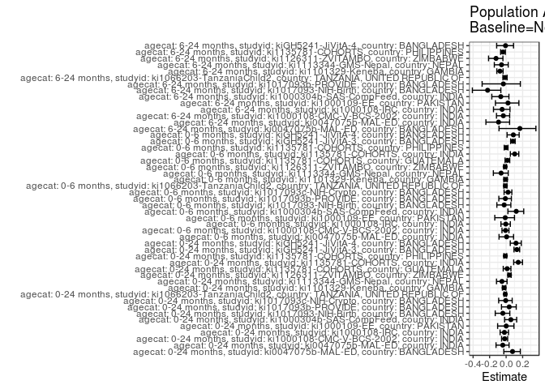

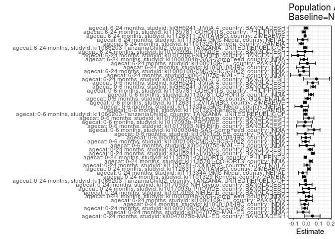

## Results Table

### Parameter: TSM

| agecat | studyid | country | intervention_level | baseline_level | estimate | ci_lower | ci_upper |
| --- | --- | --- | --- | --- | --- | --- | --- |
| 0-24 months | ki0047075b-MAL-ED | BANGLADESH | Normal or high birthweight | NA | 0.5974026 | 0.4765758 | 0.7182294 |
| 0-24 months | ki0047075b-MAL-ED | BANGLADESH | Low birthweight | NA | 0.7333333 | 0.6260841 | 0.8405826 |
| 0-24 months | ki0047075b-MAL-ED | INDIA | Normal or high birthweight | NA | 0.6393443 | 0.5417637 | 0.7369248 |
| 0-24 months | ki0047075b-MAL-ED | INDIA | Low birthweight | NA | 0.5454545 | 0.3939530 | 0.6969561 |
| 0-24 months | ki1000108-CMC-V-BCS-2002 | INDIA | Normal or high birthweight | NA | 0.6407407 | 0.5781901 | 0.7032914 |
| 0-24 months | ki1000108-CMC-V-BCS-2002 | INDIA | Low birthweight | NA | 0.5740741 | 0.4523237 | 0.6958245 |
| 0-24 months | ki1000108-IRC | INDIA | Normal or high birthweight | NA | 0.6020761 | 0.5399101 | 0.6642422 |
| 0-24 months | ki1000108-IRC | INDIA | Low birthweight | NA | 0.5544554 | 0.4573997 | 0.6515112 |
| 0-24 months | ki1000109-EE | PAKISTAN | Normal or high birthweight | NA | 0.5026738 | 0.4233327 | 0.5820149 |
| 0-24 months | ki1000109-EE | PAKISTAN | Low birthweight | NA | 0.5037037 | 0.4155315 | 0.5918759 |
| 0-24 months | ki1000304b-SAS-CompFeed | INDIA | Normal or high birthweight | NA | 0.3603239 | 0.3138121 | 0.4068357 |
| 0-24 months | ki1000304b-SAS-CompFeed | INDIA | Low birthweight | NA | 0.4164038 | 0.3631200 | 0.4696875 |
| 0-24 months | ki1017093-NIH-Birth | BANGLADESH | Normal or high birthweight | NA | 0.5377778 | 0.4650271 | 0.6105285 |
| 0-24 months | ki1017093-NIH-Birth | BANGLADESH | Low birthweight | NA | 0.4918033 | 0.4199858 | 0.5636208 |
| 0-24 months | ki1017093b-PROVIDE | BANGLADESH | Normal or high birthweight | NA | 0.5595238 | 0.4795726 | 0.6394750 |
| 0-24 months | ki1017093b-PROVIDE | BANGLADESH | Low birthweight | NA | 0.6071429 | 0.5277702 | 0.6865156 |
| 0-24 months | ki1017093c-NIH-Crypto | BANGLADESH | Normal or high birthweight | NA | 0.6257669 | 0.5439802 | 0.7075535 |
| 0-24 months | ki1017093c-NIH-Crypto | BANGLADESH | Low birthweight | NA | 0.6190476 | 0.5494076 | 0.6886877 |
| 0-24 months | ki1066203-TanzaniaChild2 | TANZANIA, UNITED REPUBLIC OF | Normal or high birthweight | NA | 0.6325301 | 0.5935887 | 0.6714715 |
| 0-24 months | ki1066203-TanzaniaChild2 | TANZANIA, UNITED REPUBLIC OF | Low birthweight | NA | 0.5128205 | 0.3457617 | 0.6798793 |
| 0-24 months | ki1101329-Keneba | GAMBIA | Normal or high birthweight | NA | 0.6766529 | 0.6449388 | 0.7083670 |
| 0-24 months | ki1101329-Keneba | GAMBIA | Low birthweight | NA | 0.5992063 | 0.5400263 | 0.6583864 |
| 0-24 months | ki1113344-GMS-Nepal | NEPAL | Normal or high birthweight | NA | 0.5688312 | 0.5139016 | 0.6237607 |
| 0-24 months | ki1113344-GMS-Nepal | NEPAL | Low birthweight | NA | 0.5000000 | 0.4344731 | 0.5655269 |
| 0-24 months | ki1126311-ZVITAMBO | ZIMBABWE | Normal or high birthweight | NA | 0.5220024 | 0.5019378 | 0.5420670 |
| 0-24 months | ki1126311-ZVITAMBO | ZIMBABWE | Low birthweight | NA | 0.5932803 | 0.5651104 | 0.6214502 |
| 0-24 months | ki1135781-COHORTS | GUATEMALA | Normal or high birthweight | NA | 0.5091575 | 0.4487028 | 0.5696122 |
| 0-24 months | ki1135781-COHORTS | GUATEMALA | Low birthweight | NA | 0.5531915 | 0.4020134 | 0.7043696 |
| 0-24 months | ki1135781-COHORTS | INDIA | Normal or high birthweight | NA | 0.2184713 | 0.1974762 | 0.2394664 |
| 0-24 months | ki1135781-COHORTS | INDIA | Low birthweight | NA | 0.3181818 | 0.2891560 | 0.3472077 |

[output cut: 68 more lines]

### Parameter: E(Y)

| agecat | studyid | country | intervention_level | baseline_level | estimate | ci_lower | ci_upper |
| --- | --- | --- | --- | --- | --- | --- | --- |
| 0-24 months | ki0047075b-MAL-ED | BANGLADESH | NA | NA | 0.6475410 | 0.5607680 | 0.7343140 |
| 0-24 months | ki0047075b-MAL-ED | INDIA | NA | NA | 0.6144578 | 0.5320591 | 0.6968566 |
| 0-24 months | ki1000108-CMC-V-BCS-2002 | INDIA | NA | NA | 0.6296296 | 0.5734927 | 0.6857666 |
| 0-24 months | ki1000108-IRC | INDIA | NA | NA | 0.5897436 | 0.5370721 | 0.6424150 |
| 0-24 months | ki1000109-EE | PAKISTAN | NA | NA | 0.5031056 | 0.4439609 | 0.5622503 |
| 0-24 months | ki1000304b-SAS-CompFeed | INDIA | NA | NA | 0.3822441 | 0.3470621 | 0.4174262 |
| 0-24 months | ki1017093-NIH-Birth | BANGLADESH | NA | NA | 0.5171569 | 0.4657250 | 0.5685888 |
| 0-24 months | ki1017093b-PROVIDE | BANGLADESH | NA | NA | 0.5811688 | 0.5245443 | 0.6377934 |
| 0-24 months | ki1017093c-NIH-Crypto | BANGLADESH | NA | NA | 0.6225806 | 0.5684562 | 0.6767051 |
| 0-24 months | ki1066203-TanzaniaChild2 | TANZANIA, UNITED REPUBLIC OF | NA | NA | 0.6258890 | 0.5879514 | 0.6638267 |
| 0-24 months | ki1101329-Keneba | GAMBIA | NA | NA | 0.6606557 | 0.6326585 | 0.6886530 |
| 0-24 months | ki1113344-GMS-Nepal | NEPAL | NA | NA | 0.5413417 | 0.4990070 | 0.5836763 |
| 0-24 months | ki1126311-ZVITAMBO | ZIMBABWE | NA | NA | 0.5443459 | 0.5279394 | 0.5607524 |
| 0-24 months | ki1135781-COHORTS | GUATEMALA | NA | NA | 0.5156250 | 0.4594779 | 0.5717721 |
| 0-24 months | ki1135781-COHORTS | INDIA | NA | NA | 0.2559618 | 0.2388022 | 0.2731215 |
| 0-24 months | ki1135781-COHORTS | PHILIPPINES | NA | NA | 0.6069712 | 0.5823178 | 0.6316245 |
| 0-24 months | kiGH5241-JiVitA-3 | BANGLADESH | NA | NA | 0.4230769 | 0.4110235 | 0.4351303 |
| 0-24 months | kiGH5241-JiVitA-4 | BANGLADESH | NA | NA | 0.2783678 | 0.2569102 | 0.2998254 |
| 0-6 months | ki0047075b-MAL-ED | INDIA | NA | NA | 0.6875000 | 0.5835705 | 0.7914295 |
| 0-6 months | ki1000108-CMC-V-BCS-2002 | INDIA | NA | NA | 0.6716418 | 0.6057305 | 0.7375531 |
| 0-6 months | ki1000108-IRC | INDIA | NA | NA | 0.6355932 | 0.5725724 | 0.6986140 |
| 0-6 months | ki1000109-EE | PAKISTAN | NA | NA | 0.5634921 | 0.4761607 | 0.6508235 |
| 0-6 months | ki1000304b-SAS-CompFeed | INDIA | NA | NA | 0.5147059 | 0.4610948 | 0.5683169 |
| 0-6 months | ki1017093-NIH-Birth | BANGLADESH | NA | NA | 0.7142857 | 0.6541352 | 0.7744362 |
| 0-6 months | ki1017093b-PROVIDE | BANGLADESH | NA | NA | 0.7837838 | 0.7252863 | 0.8422812 |
| 0-6 months | ki1017093c-NIH-Crypto | BANGLADESH | NA | NA | 0.8934010 | 0.8497799 | 0.9370221 |
| 0-6 months | ki1066203-TanzaniaChild2 | TANZANIA, UNITED REPUBLIC OF | NA | NA | 0.7014925 | 0.6517566 | 0.7512285 |
| 0-6 months | ki1101329-Keneba | GAMBIA | NA | NA | 0.8256228 | 0.7953169 | 0.8559287 |
| 0-6 months | ki1113344-GMS-Nepal | NEPAL | NA | NA | 0.6045627 | 0.5449300 | 0.6641955 |
| 0-6 months | ki1126311-ZVITAMBO | ZIMBABWE | NA | NA | 0.7481128 | 0.7311662 | 0.7650594 |
| 0-6 months | ki1135781-COHORTS | GUATEMALA | NA | NA | 0.7619048 | 0.7043195 | 0.8194900 |
| 0-6 months | ki1135781-COHORTS | INDIA | NA | NA | 0.3748545 | 0.3519572 | 0.3977518 |
| 0-6 months | ki1135781-COHORTS | PHILIPPINES | NA | NA | 0.7372654 | 0.7055895 | 0.7689413 |
| 0-6 months | kiGH5241-JiVitA-3 | BANGLADESH | NA | NA | 0.6804689 | 0.6660338 | 0.6949041 |
| 0-6 months | kiGH5241-JiVitA-4 | BANGLADESH | NA | NA | 0.6058824 | 0.5634305 | 0.6483342 |
| 6-24 months | ki0047075b-MAL-ED | BANGLADESH | NA | NA | 0.5000000 | 0.3680930 | 0.6319070 |
| 6-24 months | ki0047075b-MAL-ED | INDIA | NA | NA | 0.5465116 | 0.4258714 | 0.6671519 |
| 6-24 months | ki1000108-CMC-V-BCS-2002 | INDIA | NA | NA | 0.5609756 | 0.4682842 | 0.6536670 |
| 6-24 months | ki1000108-IRC | INDIA | NA | NA | 0.5194805 | 0.4352979 | 0.6036631 |
| 6-24 months | ki1000109-EE | PAKISTAN | NA | NA | 0.4642857 | 0.3910729 | 0.5374985 |
| 6-24 months | ki1000304b-SAS-CompFeed | INDIA | NA | NA | 0.2866242 | 0.2446853 | 0.3285631 |
| 6-24 months | ki1017093-NIH-Birth | BANGLADESH | NA | NA | 0.2931937 | 0.2273732 | 0.3590142 |
| 6-24 months | ki1017093b-PROVIDE | BANGLADESH | NA | NA | 0.2764228 | 0.1950773 | 0.3577682 |
| 6-24 months | ki1066203-TanzaniaChild2 | TANZANIA, UNITED REPUBLIC OF | NA | NA | 0.5570652 | 0.5044805 | 0.6096499 |
| 6-24 months | ki1101329-Keneba | GAMBIA | NA | NA | 0.5197568 | 0.4787855 | 0.5607282 |
| 6-24 months | ki1113344-GMS-Nepal | NEPAL | NA | NA | 0.4973545 | 0.4426760 | 0.5520330 |
| 6-24 months | ki1126311-ZVITAMBO | ZIMBABWE | NA | NA | 0.0742438 | 0.0587565 | 0.0897311 |
| 6-24 months | ki1135781-COHORTS | PHILIPPINES | NA | NA | 0.5010893 | 0.4669869 | 0.5351918 |
| 6-24 months | kiGH5241-JiVitA-4 | BANGLADESH | NA | NA | 0.1477717 | 0.1285384 | 0.1670050 |

### Parameter: RR

| agecat | studyid | country | intervention_level | baseline_level | estimate | ci_lower | ci_upper |
| --- | --- | --- | --- | --- | --- | --- | --- |
| 0-24 months | ki0047075b-MAL-ED | BANGLADESH | Normal or high birthweight | Normal or high birthweight | 1.0000000 | 1.0000000 | 1.0000000 |
| 0-24 months | ki0047075b-MAL-ED | BANGLADESH | Low birthweight | Normal or high birthweight | 1.2275362 | 0.9559833 | 1.5762254 |
| 0-24 months | ki0047075b-MAL-ED | INDIA | Normal or high birthweight | Normal or high birthweight | 1.0000000 | 1.0000000 | 1.0000000 |
| 0-24 months | ki0047075b-MAL-ED | INDIA | Low birthweight | Normal or high birthweight | 0.8531469 | 0.6214047 | 1.1713133 |
| 0-24 months | ki1000108-CMC-V-BCS-2002 | INDIA | Normal or high birthweight | Normal or high birthweight | 1.0000000 | 1.0000000 | 1.0000000 |
| 0-24 months | ki1000108-CMC-V-BCS-2002 | INDIA | Low birthweight | Normal or high birthweight | 0.8959538 | 0.7094461 | 1.1314928 |
| 0-24 months | ki1000108-IRC | INDIA | Normal or high birthweight | Normal or high birthweight | 1.0000000 | 1.0000000 | 1.0000000 |
| 0-24 months | ki1000108-IRC | INDIA | Low birthweight | Normal or high birthweight | 0.9209059 | 0.7516191 | 1.1283211 |
| 0-24 months | ki1000109-EE | PAKISTAN | Normal or high birthweight | Normal or high birthweight | 1.0000000 | 1.0000000 | 1.0000000 |
| 0-24 months | ki1000109-EE | PAKISTAN | Low birthweight | Normal or high birthweight | 1.0020489 | 0.7918834 | 1.2679922 |
| 0-24 months | ki1000304b-SAS-CompFeed | INDIA | Normal or high birthweight | Normal or high birthweight | 1.0000000 | 1.0000000 | 1.0000000 |
| 0-24 months | ki1000304b-SAS-CompFeed | INDIA | Low birthweight | Normal or high birthweight | 1.1556375 | 0.9635658 | 1.3859956 |
| 0-24 months | ki1017093-NIH-Birth | BANGLADESH | Normal or high birthweight | Normal or high birthweight | 1.0000000 | 1.0000000 | 1.0000000 |
| 0-24 months | ki1017093-NIH-Birth | BANGLADESH | Low birthweight | Normal or high birthweight | 0.9145102 | 0.7493923 | 1.1160095 |
| 0-24 months | ki1017093b-PROVIDE | BANGLADESH | Normal or high birthweight | Normal or high birthweight | 1.0000000 | 1.0000000 | 1.0000000 |
| 0-24 months | ki1017093b-PROVIDE | BANGLADESH | Low birthweight | Normal or high birthweight | 1.0851064 | 0.8938577 | 1.3172744 |
| 0-24 months | ki1017093c-NIH-Crypto | BANGLADESH | Normal or high birthweight | Normal or high birthweight | 1.0000000 | 1.0000000 | 1.0000000 |
| 0-24 months | ki1017093c-NIH-Crypto | BANGLADESH | Low birthweight | Normal or high birthweight | 0.9892624 | 0.8323930 | 1.1756946 |
| 0-24 months | ki1066203-TanzaniaChild2 | TANZANIA, UNITED REPUBLIC OF | Normal or high birthweight | Normal or high birthweight | 1.0000000 | 1.0000000 | 1.0000000 |
| 0-24 months | ki1066203-TanzaniaChild2 | TANZANIA, UNITED REPUBLIC OF | Low birthweight | Normal or high birthweight | 0.8107448 | 0.5819861 | 1.1294206 |
| 0-24 months | ki1101329-Keneba | GAMBIA | Normal or high birthweight | Normal or high birthweight | 1.0000000 | 1.0000000 | 1.0000000 |
| 0-24 months | ki1101329-Keneba | GAMBIA | Low birthweight | Normal or high birthweight | 0.8855447 | 0.7937895 | 0.9879058 |
| 0-24 months | ki1113344-GMS-Nepal | NEPAL | Normal or high birthweight | Normal or high birthweight | 1.0000000 | 1.0000000 | 1.0000000 |
| 0-24 months | ki1113344-GMS-Nepal | NEPAL | Low birthweight | Normal or high birthweight | 0.8789954 | 0.7468983 | 1.0344554 |
| 0-24 months | ki1126311-ZVITAMBO | ZIMBABWE | Normal or high birthweight | Normal or high birthweight | 1.0000000 | 1.0000000 | 1.0000000 |
| 0-24 months | ki1126311-ZVITAMBO | ZIMBABWE | Low birthweight | Normal or high birthweight | 1.1365470 | 1.0691786 | 1.2081602 |
| 0-24 months | ki1135781-COHORTS | GUATEMALA | Normal or high birthweight | Normal or high birthweight | 1.0000000 | 1.0000000 | 1.0000000 |
| 0-24 months | ki1135781-COHORTS | GUATEMALA | Low birthweight | Normal or high birthweight | 1.0864840 | 0.8065155 | 1.4636389 |
| 0-24 months | ki1135781-COHORTS | INDIA | Normal or high birthweight | Normal or high birthweight | 1.0000000 | 1.0000000 | 1.0000000 |
| 0-24 months | ki1135781-COHORTS | INDIA | Low birthweight | Normal or high birthweight | 1.4564007 | 1.2756616 | 1.6627475 |

[output cut: 68 more lines]

### Parameter: PAR

| agecat | studyid | country | intervention_level | baseline_level | estimate | ci_lower | ci_upper |
| --- | --- | --- | --- | --- | --- | --- | --- |
| 0-24 months | ki0047075b-MAL-ED | BANGLADESH | Normal or high birthweight | NA | 0.0501384 | -0.0121800 | 0.1124568 |
| 0-24 months | ki0047075b-MAL-ED | INDIA | Normal or high birthweight | NA | -0.0248864 | -0.0733864 | 0.0236135 |
| 0-24 months | ki1000108-CMC-V-BCS-2002 | INDIA | Normal or high birthweight | NA | -0.0111111 | -0.0342626 | 0.0120404 |
| 0-24 months | ki1000108-IRC | INDIA | Normal or high birthweight | NA | -0.0123325 | -0.0423687 | 0.0177036 |
| 0-24 months | ki1000109-EE | PAKISTAN | Normal or high birthweight | NA | 0.0004318 | -0.0492295 | 0.0500930 |
| 0-24 months | ki1000304b-SAS-CompFeed | INDIA | Normal or high birthweight | NA | 0.0219203 | -0.0057454 | 0.0495859 |
| 0-24 months | ki1017093-NIH-Birth | BANGLADESH | Normal or high birthweight | NA | -0.0206209 | -0.0664366 | 0.0251948 |
| 0-24 months | ki1017093b-PROVIDE | BANGLADESH | Normal or high birthweight | NA | 0.0216450 | -0.0299051 | 0.0731952 |
| 0-24 months | ki1017093c-NIH-Crypto | BANGLADESH | Normal or high birthweight | NA | -0.0031862 | -0.0541413 | 0.0477689 |
| 0-24 months | ki1066203-TanzaniaChild2 | TANZANIA, UNITED REPUBLIC OF | Normal or high birthweight | NA | -0.0066411 | -0.0162062 | 0.0029240 |
| 0-24 months | ki1101329-Keneba | GAMBIA | Normal or high birthweight | NA | -0.0159972 | -0.0298639 | -0.0021304 |
| 0-24 months | ki1113344-GMS-Nepal | NEPAL | Normal or high birthweight | NA | -0.0274895 | -0.0620070 | 0.0070279 |
| 0-24 months | ki1126311-ZVITAMBO | ZIMBABWE | Normal or high birthweight | NA | 0.0223435 | 0.0114004 | 0.0332865 |
| 0-24 months | ki1135781-COHORTS | GUATEMALA | Normal or high birthweight | NA | 0.0064675 | -0.0175440 | 0.0304790 |
| 0-24 months | ki1135781-COHORTS | INDIA | Normal or high birthweight | NA | 0.0374905 | 0.0238868 | 0.0510942 |
| 0-24 months | ki1135781-COHORTS | PHILIPPINES | Normal or high birthweight | NA | -0.0060274 | -0.0169242 | 0.0048694 |
| 0-24 months | kiGH5241-JiVitA-3 | BANGLADESH | Normal or high birthweight | NA | 0.0551345 | 0.0407087 | 0.0695603 |
| 0-24 months | kiGH5241-JiVitA-4 | BANGLADESH | Normal or high birthweight | NA | 0.0332128 | 0.0148255 | 0.0516000 |
| 0-6 months | ki0047075b-MAL-ED | INDIA | Normal or high birthweight | NA | 0.0041667 | -0.0562660 | 0.0645993 |
| 0-6 months | ki1000108-CMC-V-BCS-2002 | INDIA | Normal or high birthweight | NA | -0.0048288 | -0.0331811 | 0.0235235 |
| 0-6 months | ki1000108-IRC | INDIA | Normal or high birthweight | NA | -0.0028249 | -0.0389987 | 0.0333490 |
| 0-6 months | ki1000109-EE | PAKISTAN | Normal or high birthweight | NA | -0.0061282 | -0.0732603 | 0.0610039 |
| 0-6 months | ki1000304b-SAS-CompFeed | INDIA | Normal or high birthweight | NA | 0.0630930 | 0.0144508 | 0.1117351 |
| 0-6 months | ki1017093-NIH-Birth | BANGLADESH | Normal or high birthweight | NA | -0.0171958 | -0.0775990 | 0.0432074 |
| 0-6 months | ki1017093b-PROVIDE | BANGLADESH | Normal or high birthweight | NA | -0.0074250 | -0.0669292 | 0.0520792 |
| 0-6 months | ki1017093c-NIH-Crypto | BANGLADESH | Normal or high birthweight | NA | 0.0208520 | -0.0209627 | 0.0626667 |
| 0-6 months | ki1066203-TanzaniaChild2 | TANZANIA, UNITED REPUBLIC OF | Normal or high birthweight | NA | -0.0064440 | -0.0201935 | 0.0073055 |
| 0-6 months | ki1101329-Keneba | GAMBIA | Normal or high birthweight | NA | -0.0053296 | -0.0229022 | 0.0122430 |
| 0-6 months | ki1113344-GMS-Nepal | NEPAL | Normal or high birthweight | NA | -0.0368166 | -0.0908845 | 0.0172513 |
| 0-6 months | ki1126311-ZVITAMBO | ZIMBABWE | Normal or high birthweight | NA | -0.0088617 | -0.0216734 | 0.0039499 |
| 0-6 months | ki1135781-COHORTS | GUATEMALA | Normal or high birthweight | NA | 0.0119048 | -0.0096709 | 0.0334804 |
| 0-6 months | ki1135781-COHORTS | INDIA | Normal or high birthweight | NA | 0.0389093 | 0.0197808 | 0.0580379 |
| 0-6 months | ki1135781-COHORTS | PHILIPPINES | Normal or high birthweight | NA | -0.0002130 | -0.0170900 | 0.0166640 |
| 0-6 months | kiGH5241-JiVitA-3 | BANGLADESH | Normal or high birthweight | NA | 0.0560316 | 0.0376364 | 0.0744269 |
| 0-6 months | kiGH5241-JiVitA-4 | BANGLADESH | Normal or high birthweight | NA | 0.0530368 | 0.0090065 | 0.0970672 |
| 6-24 months | ki0047075b-MAL-ED | BANGLADESH | Normal or high birthweight | NA | 0.0833333 | -0.0206788 | 0.1873455 |
| 6-24 months | ki0047075b-MAL-ED | INDIA | Normal or high birthweight | NA | -0.0502626 | -0.1272978 | 0.0267727 |
| 6-24 months | ki1000108-CMC-V-BCS-2002 | INDIA | Normal or high birthweight | NA | -0.0190244 | -0.0636579 | 0.0256091 |
| 6-24 months | ki1000108-IRC | INDIA | Normal or high birthweight | NA | -0.0251623 | -0.0767850 | 0.0264603 |
| 6-24 months | ki1000109-EE | PAKISTAN | Normal or high birthweight | NA | 0.0105820 | -0.0550327 | 0.0761967 |
| 6-24 months | ki1000304b-SAS-CompFeed | INDIA | Normal or high birthweight | NA | -0.0185706 | -0.0483109 | 0.0111697 |
| 6-24 months | ki1017093-NIH-Birth | BANGLADESH | Normal or high birthweight | NA | -0.0657806 | -0.1166472 | -0.0149141 |
| 6-24 months | ki1017093b-PROVIDE | BANGLADESH | Normal or high birthweight | NA | -0.0092915 | -0.0726252 | 0.0540422 |
| 6-24 months | ki1066203-TanzaniaChild2 | TANZANIA, UNITED REPUBLIC OF | Normal or high birthweight | NA | -0.0074047 | -0.0214410 | 0.0066316 |
| 6-24 months | ki1101329-Keneba | GAMBIA | Normal or high birthweight | NA | -0.0386373 | -0.0579673 | -0.0193073 |
| 6-24 months | ki1113344-GMS-Nepal | NEPAL | Normal or high birthweight | NA | -0.0276455 | -0.0693577 | 0.0140667 |
| 6-24 months | ki1126311-ZVITAMBO | ZIMBABWE | Normal or high birthweight | NA | -0.0090895 | -0.0157410 | -0.0024380 |
| 6-24 months | ki1135781-COHORTS | PHILIPPINES | Normal or high birthweight | NA | -0.0189107 | -0.0333502 | -0.0044711 |
| 6-24 months | kiGH5241-JiVitA-4 | BANGLADESH | Normal or high birthweight | NA | -0.0010833 | -0.0161766 | 0.0140101 |

### Parameter: PAF

| agecat | studyid | country | intervention_level | baseline_level | estimate | ci_lower | ci_upper |
| --- | --- | --- | --- | --- | --- | --- | --- |
| 0-24 months | ki0047075b-MAL-ED | BANGLADESH | Normal or high birthweight | NA | 0.0774289 | -0.0279567 | 0.1720105 |
| 0-24 months | ki0047075b-MAL-ED | INDIA | Normal or high birthweight | NA | -0.0405014 | -0.1224266 | 0.0354441 |
| 0-24 months | ki1000108-CMC-V-BCS-2002 | INDIA | Normal or high birthweight | NA | -0.0176471 | -0.0549828 | 0.0183674 |
| 0-24 months | ki1000108-IRC | INDIA | Normal or high birthweight | NA | -0.0209117 | -0.0730536 | 0.0286965 |
| 0-24 months | ki1000109-EE | PAKISTAN | Normal or high birthweight | NA | 0.0008583 | -0.1028980 | 0.0948536 |
| 0-24 months | ki1000304b-SAS-CompFeed | INDIA | Normal or high birthweight | NA | 0.0573462 | -0.0185558 | 0.1275920 |
| 0-24 months | ki1017093-NIH-Birth | BANGLADESH | Normal or high birthweight | NA | -0.0398736 | -0.1319418 | 0.0447060 |
| 0-24 months | ki1017093b-PROVIDE | BANGLADESH | Normal or high birthweight | NA | 0.0372439 | -0.0561121 | 0.1223477 |
| 0-24 months | ki1017093c-NIH-Crypto | BANGLADESH | Normal or high birthweight | NA | -0.0051178 | -0.0902868 | 0.0733982 |
| 0-24 months | ki1066203-TanzaniaChild2 | TANZANIA, UNITED REPUBLIC OF | Normal or high birthweight | NA | -0.0106106 | -0.0260358 | 0.0045826 |
| 0-24 months | ki1101329-Keneba | GAMBIA | Normal or high birthweight | NA | -0.0242141 | -0.0454056 | -0.0034521 |
| 0-24 months | ki1113344-GMS-Nepal | NEPAL | Normal or high birthweight | NA | -0.0507803 | -0.1166004 | 0.0111598 |
| 0-24 months | ki1126311-ZVITAMBO | ZIMBABWE | Normal or high birthweight | NA | 0.0410465 | 0.0206444 | 0.0610235 |
| 0-24 months | ki1135781-COHORTS | GUATEMALA | Normal or high birthweight | NA | 0.0125430 | -0.0351219 | 0.0580130 |
| 0-24 months | ki1135781-COHORTS | INDIA | Normal or high birthweight | NA | 0.1464691 | 0.0915335 | 0.1980827 |
| 0-24 months | ki1135781-COHORTS | PHILIPPINES | Normal or high birthweight | NA | -0.0099302 | -0.0280076 | 0.0078293 |
| 0-24 months | kiGH5241-JiVitA-3 | BANGLADESH | Normal or high birthweight | NA | 0.1303180 | 0.0953912 | 0.1638962 |
| 0-24 months | kiGH5241-JiVitA-4 | BANGLADESH | Normal or high birthweight | NA | 0.1193125 | 0.0500687 | 0.1835089 |
| 0-6 months | ki0047075b-MAL-ED | INDIA | Normal or high birthweight | NA | 0.0060606 | -0.0858378 | 0.0901813 |
| 0-6 months | ki1000108-CMC-V-BCS-2002 | INDIA | Normal or high birthweight | NA | -0.0071895 | -0.0503118 | 0.0341623 |
| 0-6 months | ki1000108-IRC | INDIA | Normal or high birthweight | NA | -0.0044444 | -0.0629979 | 0.0508837 |
| 0-6 months | ki1000109-EE | PAKISTAN | Normal or high birthweight | NA | -0.0108754 | -0.1373048 | 0.1014994 |
| 0-6 months | ki1000304b-SAS-CompFeed | INDIA | Normal or high birthweight | NA | 0.1225806 | 0.0215427 | 0.2131852 |
| 0-6 months | ki1017093-NIH-Birth | BANGLADESH | Normal or high birthweight | NA | -0.0240741 | -0.1123659 | 0.0572098 |
| 0-6 months | ki1017093b-PROVIDE | BANGLADESH | Normal or high birthweight | NA | -0.0094733 | -0.0882840 | 0.0636301 |
| 0-6 months | ki1017093c-NIH-Crypto | BANGLADESH | Normal or high birthweight | NA | 0.0233400 | -0.0248250 | 0.0692414 |
| 0-6 months | ki1066203-TanzaniaChild2 | TANZANIA, UNITED REPUBLIC OF | Normal or high birthweight | NA | -0.0091861 | -0.0290217 | 0.0102672 |
| 0-6 months | ki1101329-Keneba | GAMBIA | Normal or high birthweight | NA | -0.0064553 | -0.0279662 | 0.0146055 |
| 0-6 months | ki1113344-GMS-Nepal | NEPAL | Normal or high birthweight | NA | -0.0608979 | -0.1547017 | 0.0252857 |
| 0-6 months | ki1126311-ZVITAMBO | ZIMBABWE | Normal or high birthweight | NA | -0.0118455 | -0.0291278 | 0.0051466 |
| 0-6 months | ki1135781-COHORTS | GUATEMALA | Normal or high birthweight | NA | 0.0156250 | -0.0132322 | 0.0436603 |
| 0-6 months | ki1135781-COHORTS | INDIA | Normal or high birthweight | NA | 0.1037985 | 0.0512573 | 0.1534300 |
| 0-6 months | ki1135781-COHORTS | PHILIPPINES | Normal or high birthweight | NA | -0.0002889 | -0.0234440 | 0.0223423 |
| 0-6 months | kiGH5241-JiVitA-3 | BANGLADESH | Normal or high birthweight | NA | 0.0823427 | 0.0547379 | 0.1091413 |
| 0-6 months | kiGH5241-JiVitA-4 | BANGLADESH | Normal or high birthweight | NA | 0.0875365 | 0.0113883 | 0.1578194 |
| 6-24 months | ki0047075b-MAL-ED | BANGLADESH | Normal or high birthweight | NA | 0.1666667 | -0.0861045 | 0.3606099 |
| 6-24 months | ki0047075b-MAL-ED | INDIA | Normal or high birthweight | NA | -0.0919698 | -0.2448070 | 0.0421021 |
| 6-24 months | ki1000108-CMC-V-BCS-2002 | INDIA | Normal or high birthweight | NA | -0.0339130 | -0.1168578 | 0.0428717 |
| 6-24 months | ki1000108-IRC | INDIA | Normal or high birthweight | NA | -0.0484375 | -0.1530013 | 0.0466436 |
| 6-24 months | ki1000109-EE | PAKISTAN | Normal or high birthweight | NA | 0.0227920 | -0.1295792 | 0.1546096 |
| 6-24 months | ki1000304b-SAS-CompFeed | INDIA | Normal or high birthweight | NA | -0.0647908 | -0.1734438 | 0.0338017 |
| 6-24 months | ki1017093-NIH-Birth | BANGLADESH | Normal or high birthweight | NA | -0.2243590 | -0.4088987 | -0.0639906 |
| 6-24 months | ki1017093b-PROVIDE | BANGLADESH | Normal or high birthweight | NA | -0.0336134 | -0.2906790 | 0.1722522 |
| 6-24 months | ki1066203-TanzaniaChild2 | TANZANIA, UNITED REPUBLIC OF | Normal or high birthweight | NA | -0.0132923 | -0.0389212 | 0.0117043 |
| 6-24 months | ki1101329-Keneba | GAMBIA | Normal or high birthweight | NA | -0.0743373 | -0.1129352 | -0.0370780 |
| 6-24 months | ki1113344-GMS-Nepal | NEPAL | Normal or high birthweight | NA | -0.0555851 | -0.1430804 | 0.0252130 |
| 6-24 months | ki1126311-ZVITAMBO | ZIMBABWE | Normal or high birthweight | NA | -0.1224280 | -0.2127154 | -0.0388625 |
| 6-24 months | ki1135781-COHORTS | PHILIPPINES | Normal or high birthweight | NA | -0.0377391 | -0.0670357 | -0.0092469 |
| 6-24 months | kiGH5241-JiVitA-4 | BANGLADESH | Normal or high birthweight | NA | -0.0073307 | -0.1147906 | 0.0897707 |